# Libraries

# Settings

# Sample annotations

```
       Sample Group
1    Control1  Day0
2    Control2  Day0
3    Control3  Day0
4    Control4  Day0
5    Control5  Day0
6  Treatment1  Day2
7  Treatment2  Day2
8  Treatment3  Day2
9  Treatment4  Day2
10 Treatment5  Day2
```

# Load data

## Nextflow

```
[1] TRUE
```

# Visualization

# Sums of counts

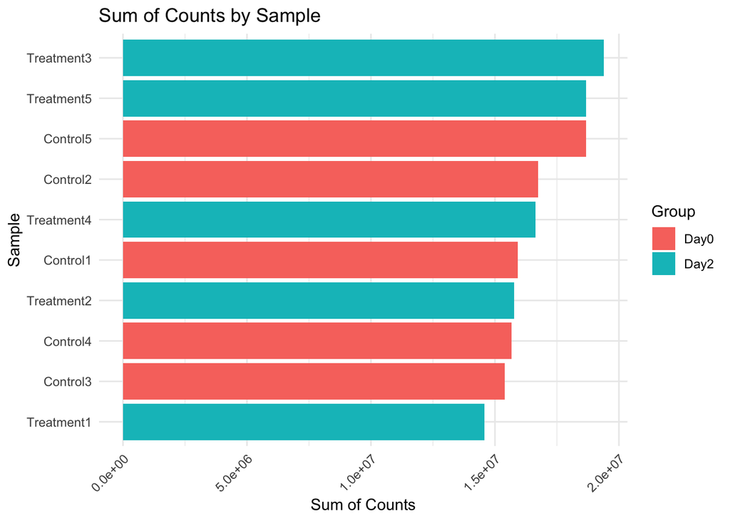

### Correlation matrix

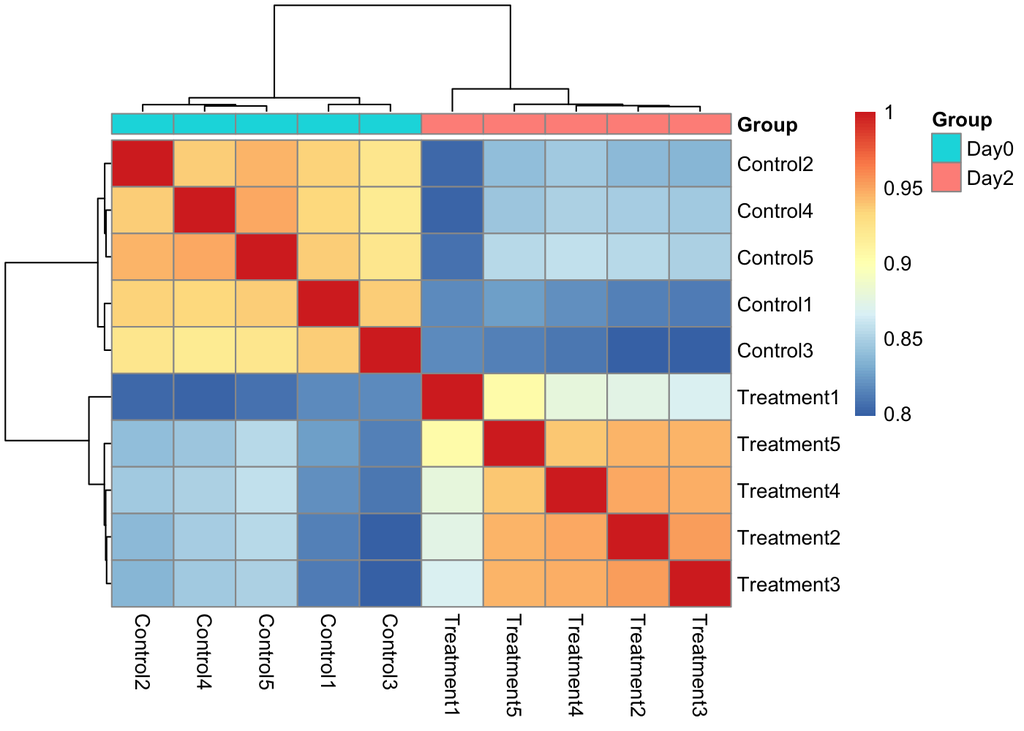

### Principal Components Analysis

|  | PC1 | PC2 | PC3 | PC4 | PC5 |
| --- | --- | --- | --- | --- | --- |
| **Standard deviation** | 44.94 | 25.13 | 14.93 | 14.03 | 13.4 |
| **Proportion of Variance** | 0.5232 | 0.1637 | 0.05776 | 0.05103 | 0.04656 |
| **Cumulative Proportion** | 0.5232 | 0.6869 | 0.7447 | 0.7957 | 0.8423 |

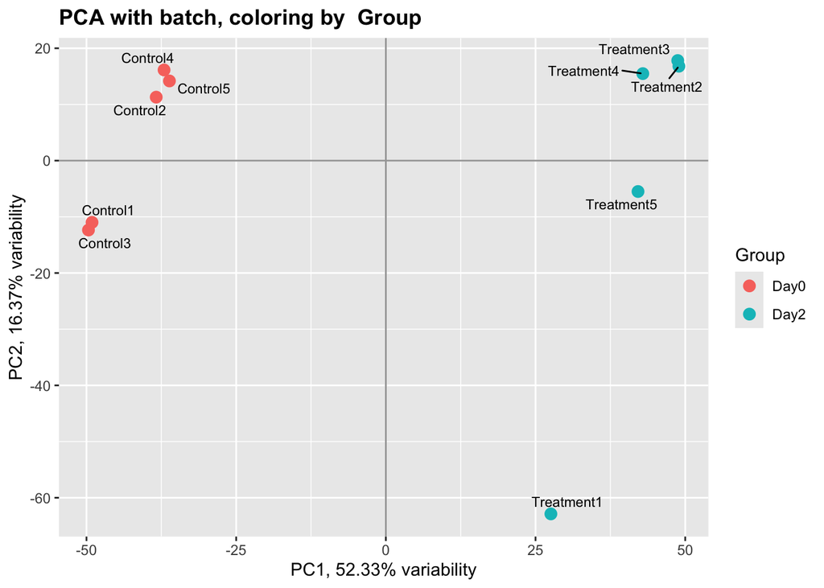

# Differential Expression Analysis

- Differentially espressed genes (DEGs) detected at False Discovery Rate (FDR) 0.3. See the total number in the table’ annotations. Top 50 or less DEGs are visualized.

Lists of differentially expressed genes are stored in Excel file /Users/mdozmorov/Documents/Data/VCU_work/Landry/2025-11.RNA-seq1/results/DEGs.xlsx. Results corresponding to Analysis 1, 2 etc. are stored in sheets with prefixes “1.”, “2.” etc. Sheets with suffexes “protein-coding”, “lncRNA”, and “other” store differentially expressed transcripts of the corresponding types. “KEGG” sheet, if present, contains pathways significantly enriched in differentially expressed protein-coding genes.

**Legend for gene lists:** “Geneid”, “symbol”, “biotype” “description” - gene annotations; “Length” - length of a gene in bp; “logFC” - log fold change; “logCPM” - average Counts Per Million, log2; “LR” - log-likelihood; “P.Val”/“adj.P.Val” - non-/FDR-adjusted p-value.

**Legend for KEGG pathway enrichment analysis:** “Term” - pathway name; “Overlap” - number of differentially expressed genes out of the total number of genes in the pathway; “P.value”, “Adjusted.P.Value” - raw and adjusted for multiple testing p-values; “Genes” - names of differentially expressed genes in the pathway.

## Analysis

```
[1] TRUE
```

```
 [1] Day0 Day2 Day0 Day2 Day0 Day2 Day0 Day2 Day0 Day2
Levels: Day0 Day2
```

```
[1] "Filtered by FDR 0.3"
```

Total number of differentially expressed genes: 9696, 4934 are upregulated, 4762 are downregulated.

Stats after selecting for protein-coding genes only.  
Total number of differentially expressed genes: 8204, 4097 are upregulated, 4107 are downregulated.

### Boxplots of top 9 genes

Y-axis - expression on log2-scale. Note the range - values > 5 indicate medium expression level. Possible negative values mean a gene is very low expressed and was adjusted into negative range by normalization.

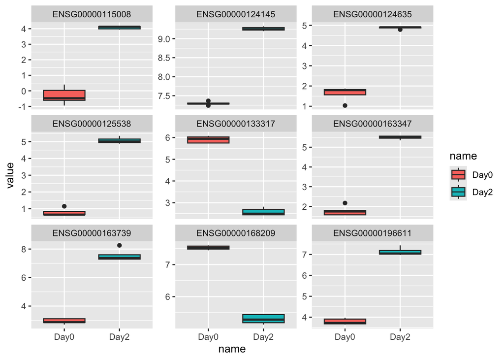

### Heatmap of top 50 differentially expressed genes

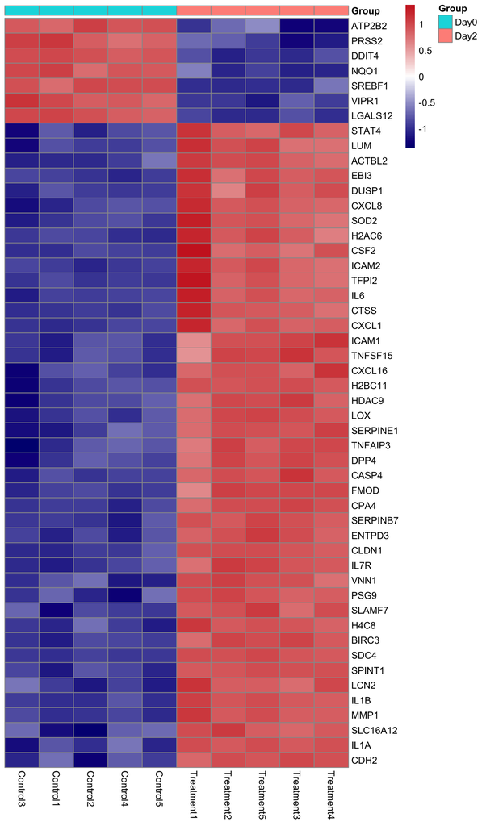

### Volcano plot

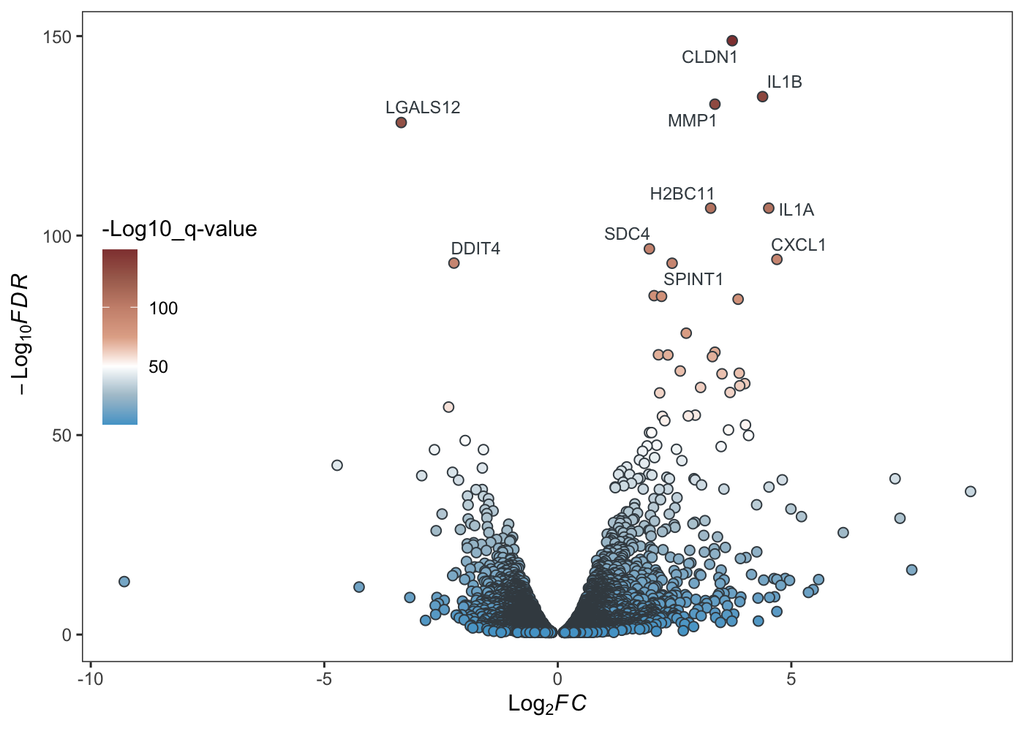

# Save data